# (Ford GoBike - Communicate Data Findings)

## by (Moheb Maher)

## Understanding the Context

> - Bay Wheels is a regional public bicycle sharing system in California's San Francisco Bay Area.
> - It was established as Bay Area Bike Share in August 2013.
> - As of January 2018, the Bay Wheels system had over 2,600 bicycles in 262 stations across San Francisco, East Bay and San Jose.
> - In June 2017 the system was officially re-launched as Ford GoBike in a partnership with Ford Motor Company.
> - The system was renamed to Bay Wheels in June 2019.
> - The system is expected to expand to 7,000 bicycles around 540 stations in San Francisco, Oakland, Berkeley, Emeryville, and San Jose.

## Investigation Overview

> - Who are Ford GoBike’s customers?
> - What are the characteristics of Customers vs. Subscribers?
> - When is the service often used? (rush hours - weekdays vs. weekends)
> - What is the average ride duration?
> - Which are the famous start and and destination station?
> - Which are the famous routes?

## Dataset Overview

> - The dataset used for this exploratory analysis consists of Bay Wheels's trip data for individual rides made in a bike-sharing system covering the greater San Francisco Bay area from Jan 2018 to Dec 2018.
> - The original dataset can be found in the download here:

>   > https://www.kaggle.com/mohebmhanna/udacity-ford-gobike-communcate-data-findings.

## Who are Ford GoBike’s customers? [1/3]

### (User type and gender)

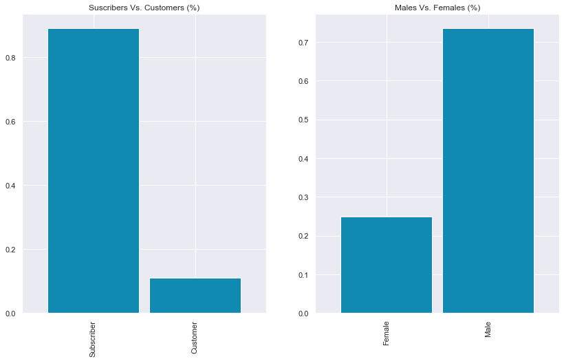

> - Since there is no user id column, we can't guarantee that these counts represent unique individuals.
> - Subscribers usually use any service more often, so it makes sense that subscribers and cusomers should be weighted differently and it will be crucial to segment our audience later on.
> - All we can conclude that:
>   > 1. The service is being used by subscribers about 8 times more often than ordinary customers.
>   > 2. The service is being used by males about 3 times more often than females.

### Who are Ford GoBike’s customers? [Part 2/3]

### (Age groups)

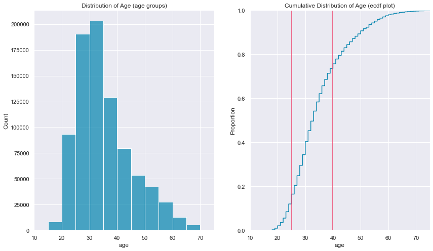

> - The histogram is skewed to the right which makes sense because riding a bike is presumed to be more difficult in older ages.
> - The age group around 30 years old is the most common pattern.
> - About 60% of bike rides were done by people aged around 25-40 years.
> - Most bike rides were done by age groups 30-35 > 25-30 > 35-40.
> - The presence of ages older than 60 years may suggest wrong enteries (ages greater than 100 were dropped at the early cleaning phase).

## Who are Ford GoBike’s customers? [3/3]

### (Age Vs. user type Vs. gender)

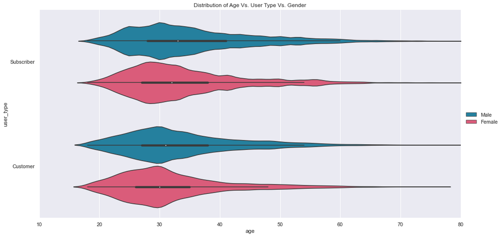

> - The distribution is nearly the same in both groups.
> - The IQR of males is slighly shifted to the right.
> - The violin plot in the male group has a longer tail (more right-skewed).
> - The age of male subscribers may have 2 peaks.

## When is the service often used? [1/4]

### (Trip counts Vs. hours)

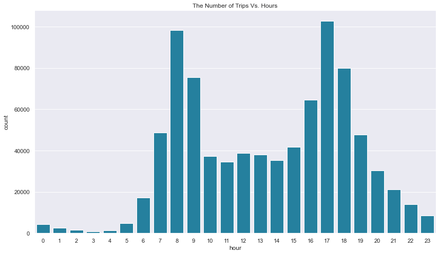

> - The distribution here is bimodal, suggesting 2 rush hours: 7am : 9am & 4pm : 7pm.
> - The rides reach their nadir between 1-4 am.

## When is the service often used? [2/4]

### (Trip counts Vs. weekdays)

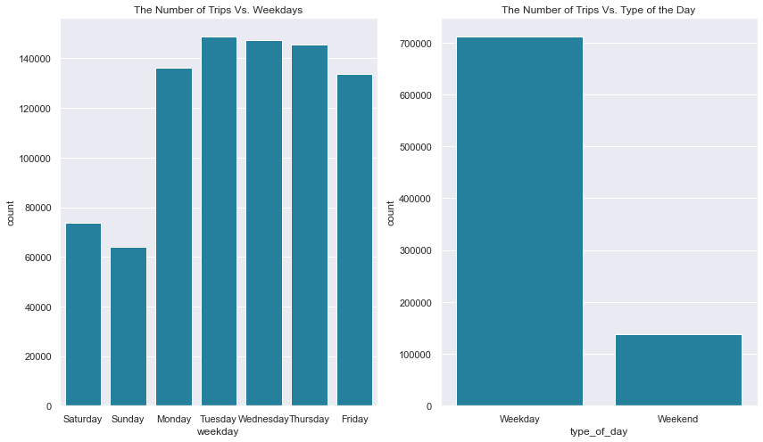

> - A common pattern is that weekdays tend to witness more rides than weekends.

## When is the service often used? [2/4]

### (Trip counts Vs. hours Vs weekdays)

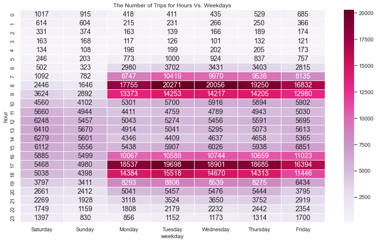

> - In weekdays, the majority of rides occur at the 2 formerly mentioned rush hours.
> - In weekends, most rides occur between 8 am - 8 pm.

## When is the service often used? [4/4]

### (Trip counts Vs. months)

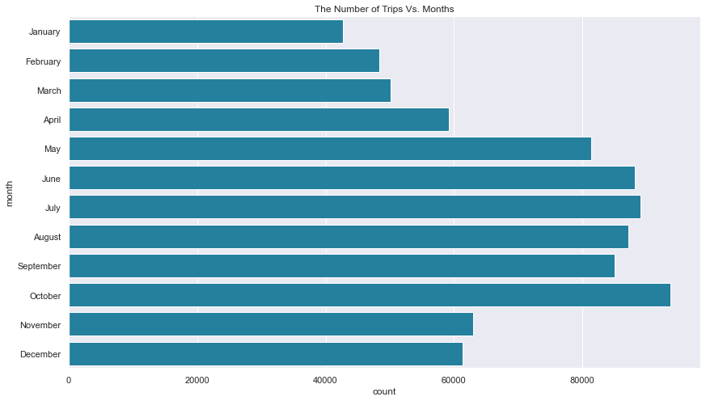

> - The common pattern here is that winter months witness less rides.

## What is the average ride duration? [1/2]

### (Distribution of duration)

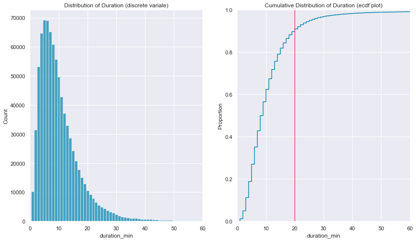

> - The distribution is skewed to the right suggesting that long rides are less common.
> - About 90% of the rides took less than 20 minutes.

## What is the average ride duration? [2/2]

### (Average duration Vs. user type Vs. type of the day)

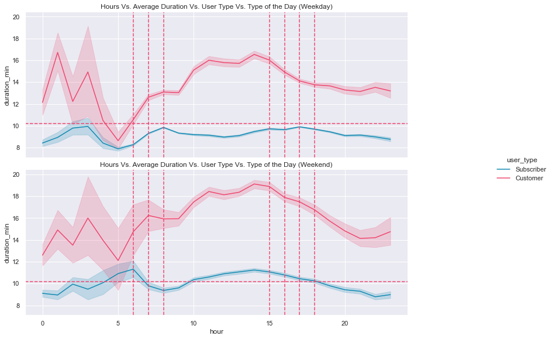

> - The average duration is generally higher for the customers group.
> - The duration is highly variable outside the rush hours.
> - The variation in duration is higher for the customers group than subscribers group.

## Which are the famous start and and destination station? [1/3]

### (Top 20 start stations)

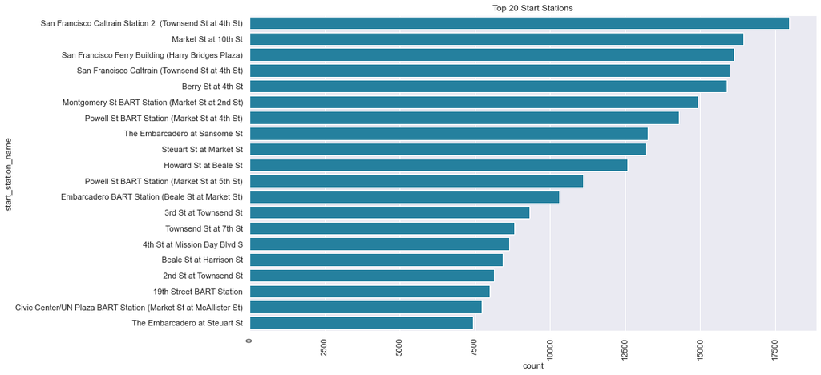

> - Top 10 start stations:
>   > 1. San Francisco Caltrain Station 2 (Townsend St at 4th St).
>   > 2. Market St at 10th St.
>   > 3. San Francisco Ferry Building (Harry Bridges Plaza).
>   > 4. San Francisco Caltrain (Townsend St at 4th St).
>   > 5. Berry St at 4th St.
>   > 6. Montgomery St BART Station (Market St at 2nd St).
>   > 7. Powell St BART Station (Market St at 4th St).
>   > 8. The Embarcadero at Sansome St.
>   > 9. Steuart St at Market St.
>   > 10. Howard St at Beale St.

## Which are the famous start and and destination station? [2/3]

### (Top 20 end stations)

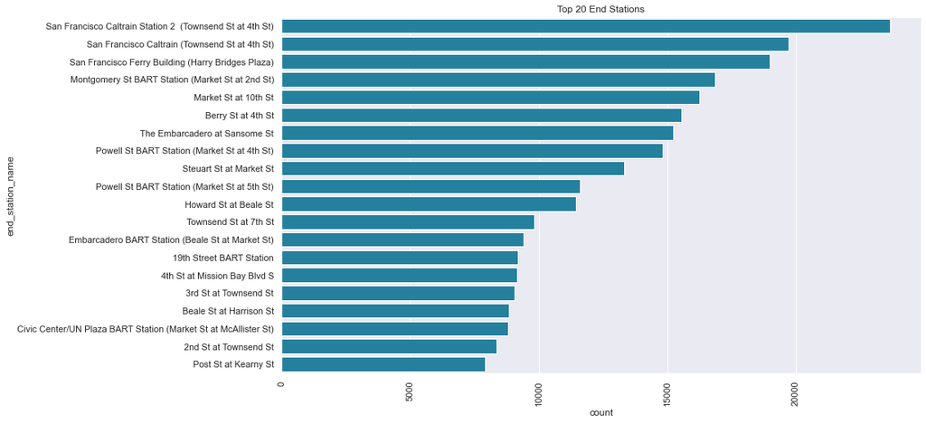

> - Top 10 end stations:
>   > 1. San Francisco Caltrain Station 2 (Townsend St at 4th St).
>   > 2. San Francisco Caltrain (Townsend St at 4th St).
>   > 3. San Francisco Ferry Building (Harry Bridges Plaza).
>   > 4. Montgomery St BART Station (Market St at 2nd St).
>   > 5. Market St at 10th St.
>   > 6. Berry St at 4th St.
>   > 7. The Embarcadero at Sansome St.
>   > 8. Powell St BART Station (Market St at 4th St).
>   > 9. Steuart St at Market St.
>   > 10. Powell St BART Station (Market St at 5th St).

## Which are the famous start and and destination station? [3/3]

### (Trip counts Vs. start station Vs. end stations)

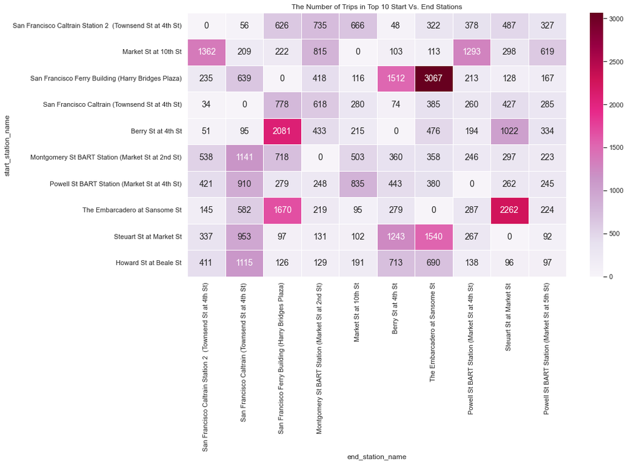

> - Top 5 are:
>   > 1. San Francisco Ferry Building (Harry Bridges Plaza) >>> The Embarcadero at Sansome St.
>   > 2. The Embarcadero at Sansome St >>> Steuart St at Market St.
>   > 3. Berry St at 4th St >>> San Francisco Ferry Building (Harry Bridges Plaza).
>   > 4. The Embarcadero at Sansome St >>> San Francisco Ferry Building (Harry Bridges Plaza).
>   > 5. Steuart St at Market St >>> The Embarcadero at Sansome St.

## Which are the famous routes?

### (After dropping duplicates)

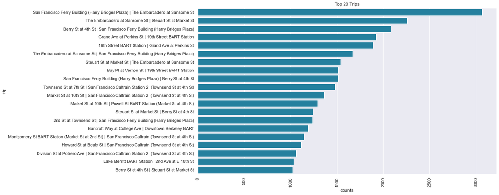

> - Top 10 trips:
>   > 1. San Francisco Ferry Building (Harry Bridges Plaza) | The Embarcadero at Sansome St.
>   > 2. The Embarcadero at Sansome St | Steuart St at Market St.
>   > 3. Berry St at 4th St | San Francisco Ferry Building (Harry Bridges Plaza).
>   > 4. Grand Ave at Perkins St | 19th Street BART Station.
>   > 5. 19th Street BART Station | Grand Ave at Perkins St.
>   > 6. The Embarcadero at Sansome St | San Francisco Ferry Building (Harry Bridges Plaza).
>   > 7. Steuart St at Market St | The Embarcadero at Sansome St.
>   > 8. Bay Pl at Vernon St | 19th Street BART Station.
>   > 9. San Francisco Ferry Building (Harry Bridges Plaza) | Berry St at 4th St.
>   > 10. Townsend St at 7th St | San Francisco Caltrain Station 2 (Townsend St at 4th St).

## That is all!

### I hope you found that informative.